# Lab 04 - Data Visualization

# Learning Goals

- Read in and prepare the meteorological dataset
- Create several graphs with different `geoms()` in `ggplot2`
- Create a facet graph
- Conduct some customizations of the graphs
- Create a more detailed map using `leaflet()`

# Lab Description

We will again work with the meteorological data presented in lecture.

**The objective of the lab is to examine the association between weekly average dew point temperature and wind speed in four regions of the US and by elevation.**

# Steps

### 1. Read in the data

First download and then read in with data.table:fread()

This is the same met_data as we used in lab 03, so you can choose to move that file to your current project directory instead of re-downloading.

```r
download.file(
  "https://raw.githubusercontent.com/JSC370/jsc370-2022/main/labs/lab03/met_all.gz",
  destfile = "met_all.gz",
  method   = "curl",
  timeout  = 60
  )

met <- data.table::fread("met_all.gz")
```

### 2. Prepare the data

- Remove temperatures less than -17C
- Make sure there are no missing data in the key variables coded as 9999, 999, etc
- Generate a date variable using the functions `as.Date()` (hint: You will need the following to create a date `paste(year, month, day, sep = "-")`).
- Using the `data.table::week` function, keep the observations of the first week of the month.
- Compute the mean by station of the variables `temp`, `rh`, `wind.sp`, `vis.dist`, `dew.point`, `lat`,`lon`, and `elev`.
- Create a region variable for NW, SW, NE, SE based on lon = -98.00 and lat = 39.71 degrees
- Create a categorical variable for elevation (breakpoint 252 m)

### 3. Use `geom_violin` to examine the wind speed and dew point temperature by region

You saw how to use `geom_boxplot` in class. Try using `geom_violin` instead (take a look at the help). (hint: You will need to set the `x` aesthetic to 1)

- Use facets
- Make sure to deal with `NA` category
- Describe what you observe in the graph

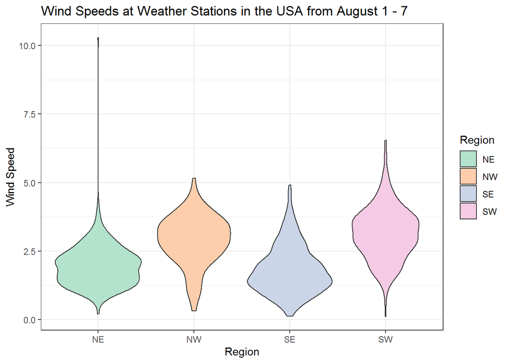

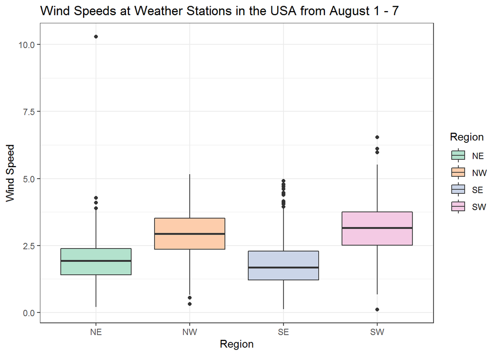

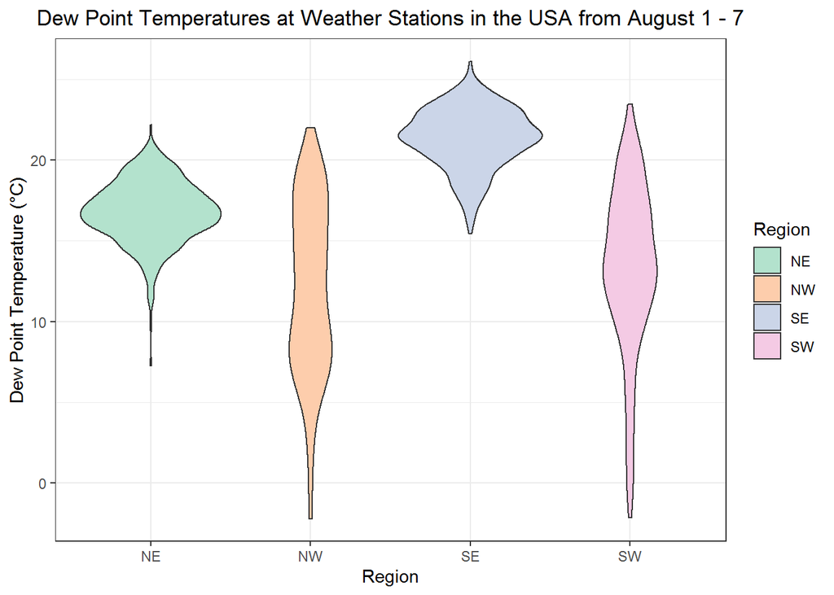

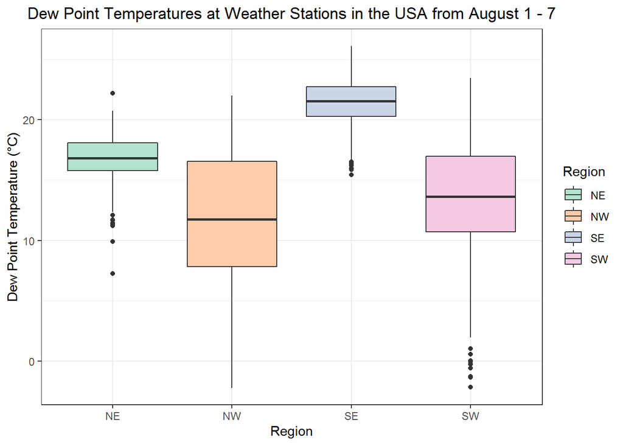

Based on the plots above, the Eastern portion of the United States seems to have higher average dew point temperatures and lower wind speeds than the Western half of the country.

The variances of the recorded wind speeds in each of the four regions of the United States seem to be approximately equal, with a slightly higher variance in the Southwest than in the other three regions, but not remarkably higher. However, the variances among dew point temperatures in the Western regions are significantly higher than the variances of dew point temperatures in the Eastern half of the United States. This may be occurring because of the ranges of elevations in the Western half of the United States, as the West has the Rockies and the Pacific coast, whereas the Eastern half of the United states has fewer differences in climate (in comparison) to the West.

### 4. Use `geom_jitter` with `stat_smooth` to examine the association between dew point temperature and wind speed by region

- Color points by region
- Make sure to deal with `NA` category
- Fit a linear regression line by region
- Describe what you observe in the graph

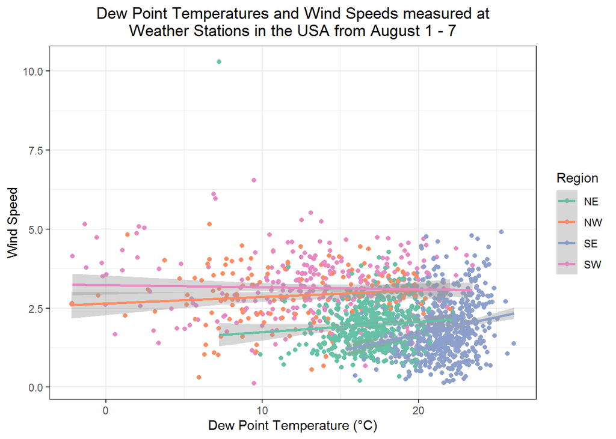

Based on the plot above, there appears to be a slightly positive correlation between the dew point temperature and measured wind speed for each region except for the Southwest, which appears to have a slightly negative correlation between these values instead.

The Northwest and Southwest both have correlations which are quite close to zero, and the dew point temperatures are very spread out throughout the graph (as we saw in the previous question due to the high variance) whereas the Northeast and Southeast have slightly higher slopes in their regression lines, and the points for these regions are more clustered together.

It would appear that there is a somewhat positive correlation overall between the dew point temperature and the wind speed, but there are likely underlying factors which affect both of these values, such as elevations or general climate patterns in these regions.

### 5. Use `geom_bar` to create barplots of the weather stations by elevation category coloured by region

- Bars by elevation category using `position="dodge"`
- Change colors from the default. Color by region using `scale_fill_brewer` see [this](http://rstudio-pubs-static.s3.amazonaws.com/5312_98fc1aba2d5740dd849a5ab797cc2c8d.html)
- Create nice labels on axes and add a title
- Try a different theme
- Describe what you observe in the graph
- Make sure to deal with `NA`

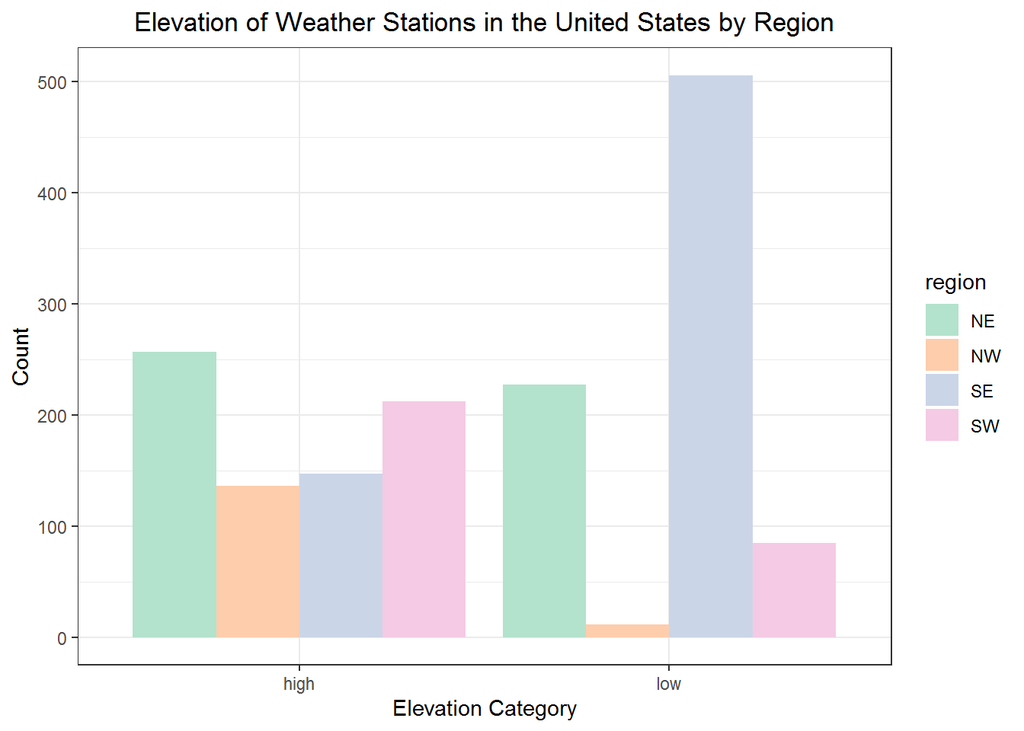

Overall, we see that the Northeastern United States has slightly more high-elevation weather stations than low-elevation stations, but these numbers are pretty close to even among weather stations in the Northeast. It is likely that most of the low-elevation weather stations are close to the Atlantic coast, whereas the high-elevation stations are in the Appalachian Mountains.

The Southeast primarily has low elevation stations, which is likely because of the overall lack of particularly high mountains in the Southeastern United States, outside of the southern portion of the Appalachin Mountains.

The Northwest has very few low-elevation stations, and almost all of the weather stations in the Northwest are located well above sea level, as the majority of the Northwestern United States is situated in the Rocky Mountains.

The Southwest has more high-elevation stations than low-elevation stations, likely due to the Rocky Mountains as well, and other mountain ranges in California, but there are still many lower-elevation stations, which are likely close to the coast of the Pacific ocean.

### 6. Use `stat_summary` to examine mean dew point and wind speed by region with standard deviation error bars

- Make sure to remove `NA`
- Use fun.data=“mean_sdl” in `stat_summary`
- Add another layer of `stats_summary` but change the geom to `"errorbar"` (see the help).
- Describe the graph and what you observe

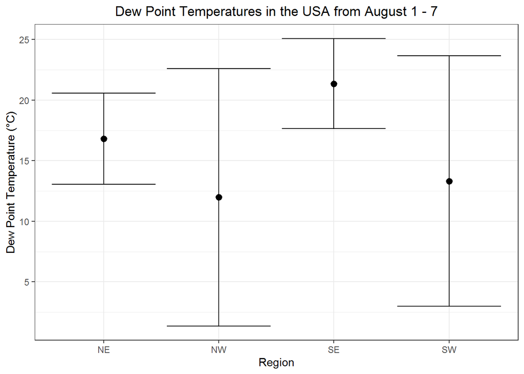

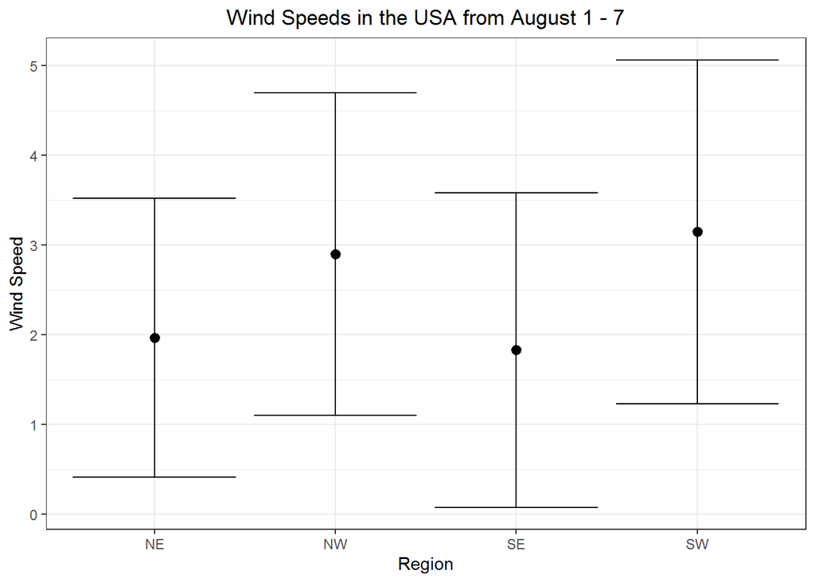

- Dew point temperature is higher on average in the Northeast and the Southeast than it is in the Northwest and Southwest parts of the United States. However, the dew point temperature has a significantly larger range of values in the Western half of the United States than it does in the Eastern half.
- Wind speed is higher on average in the Northwest and Southwestern parts of the United States than it is in the Eastern parts of the country. The range of wind speeds in each of the four regions of the United States is approximately equal, with the Northeastern region having the smallest range, but this range is not too much smaller than the other three regions’ ranges.

### 7. Make a map showing the spatial trend in relative h in the US

- Make sure to remove `NA`
- Use leaflet()
- Make a colour palette with custom colours
- Use `addMarkers` to include the top 10 places in relative h (hint: this will be useful `rank(-rh) <= 10`)
- Add a legend

[interactive chart not shown]

- Describe trend in RH across the US

Overall, the relative humidity in the US seems to decrease as we move further towards the west. Many of the high-humidity areas of the United States appear to be coastal areas, particularly the ones near the Gulf of Mexico and the East Coast of the US.

As the weather stations move further west, the relative humidity appears to decrease, and based on the increasing size of the circles marking the locations of these weather stations, we see that the elevation of these weather stations is increasing and the relative humidity is decreasing. This makes sense, as the areas in the US which have high elevations for their weather stations and low relative humidities are primarily weather stations located in the Rocky Mountains, which explains the low humidity and high elevation.

As we approach the West coast of the United States, the humidity increases again similar to the high humidity values found on the Eastern Seaboard and Gulf of Mexico, which also makes sense, as the humidity would be higher in the regions close to the ocean, and these areas are not high-elevation areas.

### 8. Use a ggplot extension

- Pick and extension (except cowplot) from [here](https://exts.ggplot2.tidyverse.org/gallery/) and make a plot of your choice using the met data (or met_avg)
- Might want to try examples that come with the extension first (e.g. ggtech, gganimate, ggforce)

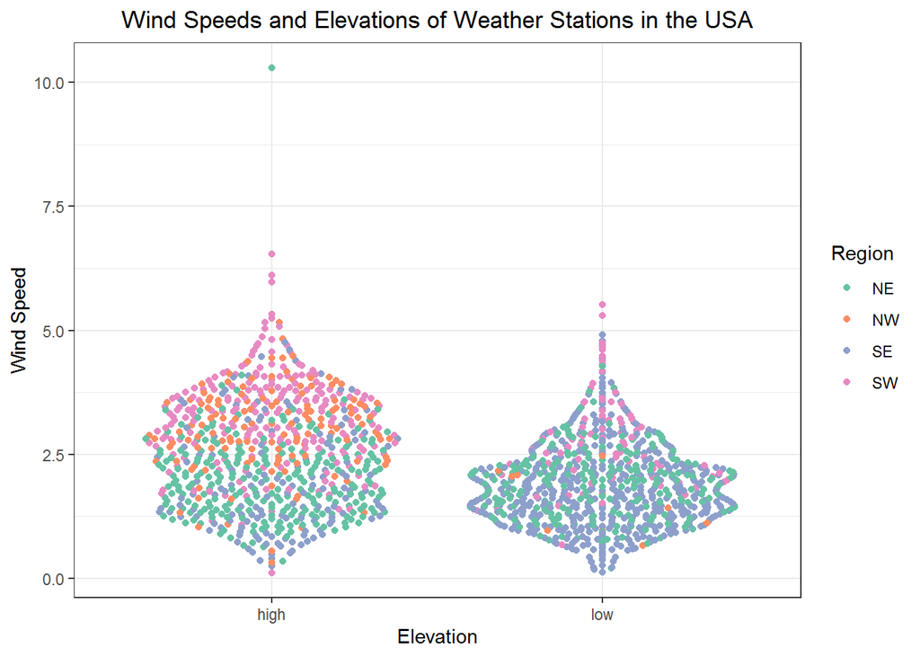